[Math 441 portfolio](https://rctcwyvrn.github.io/math441-learning-portfolio/)

# Exploring a smaller matrix representation of network flows

The source code for this entry can be found at https://github.com/rctcwyvrn/math441-learning-portfolio/blob/master/smaller_network_matrix_tests.ipynb

During class we modelled network flows using a $ n^2-n $ sized matrix and naturally the question I had was, is it more efficient to just have a $ mxn $ sized matrix?

Recall that during lecture we did our optimization with a $n^2 - n$ sized vector $x$ which was a flattened representation of $x$ as a matrix where each $x_{i,j}$ represented the flow between nodes $i$ and $j$. Since not all edges exist in the graph, the $x_{i,j}$ where $i$ and $j$ do not share an edge were eliminated using constraints on $u$ by setting the limit for the flow to be $0$.

However the list of edges is known from the start, and what we can do instead is to have a vector of size $m$ where $m$ is the number of edges, and have $x_{k}$ represent the flow on edge $k$.

This representation (dubbed "edges only") will always be at most the size of the representation we looked at in class (dubbed "big matrix"), but they do represent the same problem so the question is will `linprog` be able to recognize this fact or will the edges only representation be faster?

My theory is that it won't, because `linprog` knows that those variables must be set to 0 by the constraint on $ u $ and the fact that $u_{ij} = 0$ if there isn't an edge between nodes i and j. If linprog is smart it should zero out those variables at the start and then end up with the exact same reduced matrix that we would get from just considering the edges.

Let's start with the plotting code that we wrote during lecture

```python
import numpy as np
import scipy.linalg as la
# import pandas as pd
import matplotlib.pyplot as plt
from scipy.optimize import linprog
import random

def plotG(V,E,arrow_length=0.5,arrow_width=0.01,figsize=None):
    V = np.array(V); E = np.array(E)
    if figsize:
        plt.figure(figsize=figsize)
    for e in E:
        i,j = e
        plt.plot([V[i,0],V[j,0]],[V[i,1],V[j,1]],'k')
        plt.arrow(V[i,0],V[i,1],(V[j,0] - V[i,0])*arrow_length,(V[j,1] - V[i,1])*arrow_length,width=arrow_width,color='k')
    plt.plot(V[:,0],V[:,1],'w.',markersize=40,markeredgecolor='k')
    for i in range(V.shape[0]):
        plt.annotate(str(i),xy=V[i,:],ha='center',va='center')
    plt.axis(False)
    plt.show()
```

Naturally we also want to benchmark this so let's make a function that generates a similar graph to the one used in class

- one center node with $n$ resource
- $n$ outer nodes connected to each other by a cost of $1$
- each outer node is connected to the center node by a random cost

This gives us a not very well connected graph, so by just considering the edges we should be able to make a much smaller matrix than the one we made in class

```python
def make_graph(n):
    center = (0,0)
    offset_amt = 4*10 / n
    divisor = n // 4
    V = [center]
    E = []
    def make_pt(corner, offset):
        if corner == 0:
            return (-5 + offset,-5)
        if corner == 1:
            return (5, -5 + offset)
        if corner == 2:
            return (5 - offset, 5)
        if corner == 3:
            return (-5, 5 - offset)

    for i in range(n):
        corner = i // divisor
        offset = offset_amt * (i % divisor)
        V.append(make_pt(corner, offset))
        i += 1
        E.append((0,i)) # center to new edge pt
        if i == 1:
            E.append((i,n)) # previous
        else:
            E.append((i,i-1)) # previous
        if i == n:
            E.append((i,1)) # next
        else:
            E.append((i,i+1)) # next
    return (V, E)
```

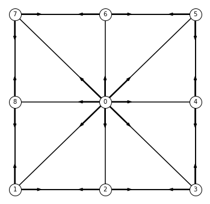

```python
V,E = make_graph(8)
plotG(V,E,arrow_width=0.05,arrow_length=0.25,figsize=(6,6))
```

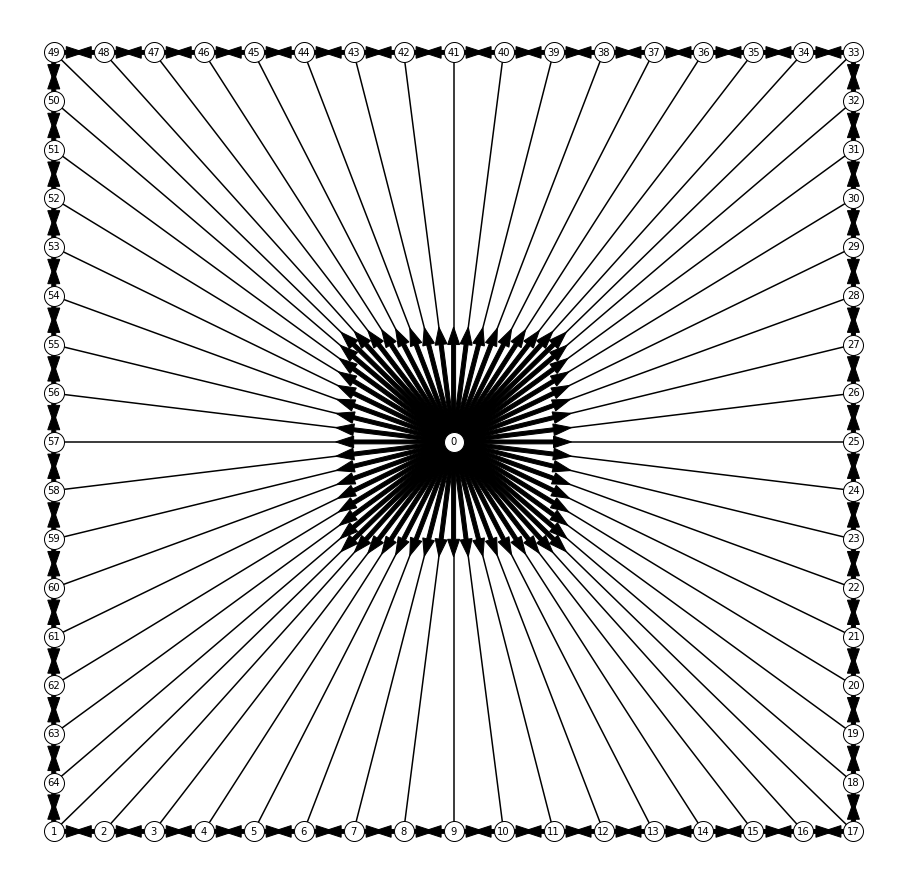

```python
V,E = make_graph(64)
plotG(V,E,arrow_width=0.05,arrow_length=0.25,figsize=(16,16))
```

## Making the matrix

So now that we have our set of graphs that we'll benchmark on, let's work on developing the smaller matrix representation.

First we need to make the cost vector for the smaller matrix. Recall that we want a problem where each outer node has a cost of 1 to both of it's neighbours, and a random cost to reach from the center.

Since the two problems have different variable layouts, we'll need to write one function for each

```python
def make_costs_big_matrix(n, center_costs):
    # all outer costs are just 1
    c = np.ones((n+1)**2 - n -1)
    # center to outside costs are given by the array
    for i, cost in enumerate(center_costs):
        c[i] = cost
    return c

def make_costs_edges_only_matrix(E, center_costs):
    c = np.zeros(len(E))
    counter = 0
    for i, edge in enumerate(E):
        if edge[0] != 0 and edge[1] != 0:
            # all outer costs are just 1
            c[i] = 1
        else:
            c[i] = center_costs[counter]
            counter+=1
    return c
```

```python
n = 8
V,E = make_graph(n)
print(len(V)) # remember we have n+1 nodes!
center_costs = [random.randint(1,10) for _ in range(n)]
print(center_costs)
print(make_costs_big_matrix(n, center_costs).reshape(n+1,n))
print(E)
print(make_costs_edges_only_matrix(E, center_costs))
```

```
9
[2, 6, 2, 6, 1, 10, 5, 7]
[[ 2.  6.  2.  6.  1. 10.  5.  7.]
 [ 1.  1.  1.  1.  1.  1.  1.  1.]
 [ 1.  1.  1.  1.  1.  1.  1.  1.]
 [ 1.  1.  1.  1.  1.  1.  1.  1.]
 [ 1.  1.  1.  1.  1.  1.  1.  1.]
 [ 1.  1.  1.  1.  1.  1.  1.  1.]
 [ 1.  1.  1.  1.  1.  1.  1.  1.]
 [ 1.  1.  1.  1.  1.  1.  1.  1.]
 [ 1.  1.  1.  1.  1.  1.  1.  1.]]
[(0, 1), (1, 8), (1, 2), (0, 2), (2, 1), (2, 3), (0, 3), (3, 2), (3, 4), (0, 4), (4, 3), (4, 5), (0, 5), (5, 4), (5, 6), (0, 6), (6, 5), (6, 7), (0, 7), (7, 6), (7, 8), (0, 8), (8, 7), (8, 1)]
[ 2.  1.  1.  6.  1.  1.  2.  1.  1.  6.  1.  1.  1.  1.  1. 10.  1.  1.
  5.  1.  1.  7.  1.  1.]
```

We already see how much larger the vectors are going to be for the big matrix formulation compared to the edges only one, but let's continue. We now need to make the balance matricies. Luckily for me we already have the code for one of them from lecture

```python
def make_balance_big_matrix(n):
    n = n + 1
    blocks = []
    for k in range(n):
        block = np.insert(np.eye(n-1),k,-1,axis=0)
        blocks.append(block)
    A = np.hstack(blocks)
    return A

def make_balance_edges_only(n,E):
    A = np.zeros((n+1, len(E)))
    # flows for node #row
    for row in range(n+1):
        for col, edge in enumerate(E):
            if edge[0] == row:
                A[row, col] = -1
            elif edge[1] == row:
                A[row, col] = 1
            else:
                A[row, col] = 0
    return A
```

```python
n = 8
V,E = make_graph(n)
print(make_balance_edges_only(n, E).reshape((n+1, len(E))))
```

```
[[-1.  0.  0. -1.  0.  0. -1.  0.  0. -1.  0.  0. -1.  0.  0. -1.  0.  0.
  -1.  0.  0. -1.  0.  0.]
 [ 1. -1. -1.  0.  1.  0.  0.  0.  0.  0.  0.  0.  0.  0.  0.  0.  0.  0.
   0.  0.  0.  0.  0.  1.]
 [ 0.  0.  1.  1. -1. -1.  0.  1.  0.  0.  0.  0.  0.  0.  0.  0.  0.  0.
   0.  0.  0.  0.  0.  0.]
 [ 0.  0.  0.  0.  0.  1.  1. -1. -1.  0.  1.  0.  0.  0.  0.  0.  0.  0.
   0.  0.  0.  0.  0.  0.]
 [ 0.  0.  0.  0.  0.  0.  0.  0.  1.  1. -1. -1.  0.  1.  0.  0.  0.  0.
   0.  0.  0.  0.  0.  0.]
 [ 0.  0.  0.  0.  0.  0.  0.  0.  0.  0.  0.  1.  1. -1. -1.  0.  1.  0.
   0.  0.  0.  0.  0.  0.]
 [ 0.  0.  0.  0.  0.  0.  0.  0.  0.  0.  0.  0.  0.  0.  1.  1. -1. -1.
   0.  1.  0.  0.  0.  0.]
 [ 0.  0.  0.  0.  0.  0.  0.  0.  0.  0.  0.  0.  0.  0.  0.  0.  0.  1.
   1. -1. -1.  0.  1.  0.]
 [ 0.  1.  0.  0.  0.  0.  0.  0.  0.  0.  0.  0.  0.  0.  0.  0.  0.  0.
   0.  0.  1.  1. -1. -1.]]
```

Our $b$ vector is the same for both problems, the center node has all the resource and each outer node requires 1

```python
def make_b(n):
    n = n+1
    b = -np.ones(n)
    b[0] = n-1
    return b

make_b(n)
```

```
array([ 8., -1., -1., -1., -1., -1., -1., -1., -1.])
```

Next we need to build our limit for the flow across each edge, which we set to 1.5.

For the big matrix we need to set some of these limits to 0 to account for the edges that don't actually exist. In contrast the edges only formulation only just has to set the limit.

This is the key question I wanted to answer, does `linprog` see these variables will all be set to $0$ and remove them from the problem before beginning matrix simplex?

```python
# limit for all flows
limit = 1.5

def make_u_big_matrix(n, E):
    u_big_matrix = np.zeros((n+1)**2 - n -1)
    idx = 0
    for i in range(n+1):
        for j in range(n+1):
            # print(idx, i, j, (i,j) in E)
            if (i,j) in E:
                u_big_matrix[idx] = limit
            if i != j:
                idx += 1
    return u_big_matrix

def make_u_edges_only(E):
    return np.ones(len(E)) * limit
```

```python
print(make_u_big_matrix(n, E).reshape(n+1,n))
```

```
[[1.5 1.5 1.5 1.5 1.5 1.5 1.5 1.5]
 [0.  1.5 0.  0.  0.  0.  0.  1.5]
 [0.  1.5 1.5 0.  0.  0.  0.  0. ]
 [0.  0.  1.5 1.5 0.  0.  0.  0. ]
 [0.  0.  0.  1.5 1.5 0.  0.  0. ]
 [0.  0.  0.  0.  1.5 1.5 0.  0. ]
 [0.  0.  0.  0.  0.  1.5 1.5 0. ]
 [0.  0.  0.  0.  0.  0.  1.5 1.5]
 [0.  1.5 0.  0.  0.  0.  0.  1.5]]
```

Now that we have all the components, let's put it all together

```python
I = np.eye((n+1)**2 - n -1)
c = make_costs_big_matrix(n, center_costs)
u = make_u_big_matrix(n, E)
b = make_b(n)
A = make_balance_big_matrix(n)
solution = linprog(c,A_eq=A[:n-1],b_eq=-b[:n-1],A_ub=I,b_ub=u)
solution.x.round(2).reshape(n+1,n)
```

```
array([[ 1.5,  1. ,  1.5,  0.5,  1.5,  0. ,  1.5,  0.5],
       [ 0. ,  0. ,  0. ,  0. ,  0. , -0. ,  0. ,  0.5],
       [ 0. ,  0. ,  0. ,  0. ,  0. , -0. ,  0. ,  0. ],
       [ 0. ,  0. ,  0. ,  0.5, -0. , -0. , -0. , -0. ],
       [ 0. ,  0. ,  0. ,  0. ,  0. , -0. ,  0. ,  0. ],
       [ 0. ,  0. ,  0. ,  0. ,  0. ,  0.5,  0. ,  0. ],
       [ 0. ,  0. ,  0. ,  0. ,  0. ,  0. ,  0. ,  0. ],
       [ 0. ,  0. ,  0. ,  0. ,  0. ,  0. ,  0.5,  0. ],
       [ 0. ,  0. ,  0. ,  0. ,  0. ,  0. ,  0. ,  0. ]])
```

```python
I = np.eye(len(E))
c = make_costs_edges_only_matrix(E, center_costs)
u = make_u_edges_only(E)
b = make_b(n)
A = make_balance_edges_only(n, E)
solution = linprog(c,A_eq=A[:n-1],b_eq=-b[:n-1],A_ub=I,b_ub=u)
list(zip(solution.x.round(2), E))
```

```
[(1.5, (0, 1)),
 (0.5, (1, 8)),
 (0.0, (1, 2)),
 (1.0, (0, 2)),
 (0.0, (2, 1)),
 (0.0, (2, 3)),
 (1.5, (0, 3)),
 (0.0, (3, 2)),
 (0.5, (3, 4)),
 (0.5, (0, 4)),
 (0.0, (4, 3)),
 (0.0, (4, 5)),
 (1.5, (0, 5)),
 (0.0, (5, 4)),
 (0.5, (5, 6)),
 (0.0, (0, 6)),
 (0.0, (6, 5)),
 (0.0, (6, 7)),
 (1.5, (0, 7)),
 (0.5, (7, 6)),
 (0.0, (7, 8)),
 (0.5, (0, 8)),
 (0.0, (8, 7)),
 (0.0, (8, 1))]
```

Although the two answers are formatted differently, we can see that they result in the same solution!

Phew, I didn't do anything wrong!

Now let's set up some functions that we can benchmark. For the big matrix solution we perform an extra step to convert the given solution to the same form as the edges only solution. This runs in $n^2$ time, but since $n$ is small (<100) this should make no difference.

```python
def run_big_matrix(n, center_costs):
    V,E = make_graph(n)
    I = np.eye((n+1)**2 - n -1)
    c = make_costs_big_matrix(n, center_costs)
    u = make_u_big_matrix(n, E)
    b = make_b(n)
    A = make_balance_big_matrix(n)
    solution = linprog(c,A_eq=A,b_eq=-b,A_ub=I,b_ub=u)
    solution = solution.x.round(2)

    # recover the flows for each edge and put them into the same order as the edge only model
    idx = 0
    unordered = {}
    for i in range(n+1):
        for j in range(n+1):
            # print(idx, i, j, (i,j) in E)
            if (i,j) in E:
                unordered[(i,j)] = solution[idx]
            if i != j:
                idx += 1
    ordered = [(unordered[edge], edge) for edge in E]
    return ordered
```

```python
def run_edges_only_matrix(n, center_costs):
    V,E = make_graph(n)
    I = np.eye(len(E))
    c = make_costs_edges_only_matrix(E, center_costs)
    u = make_u_edges_only(E)
    b = make_b(n)
    A = make_balance_edges_only(n, E)
    solution = linprog(c,A_eq=A,b_eq=-b,A_ub=I,b_ub=u)
    return list(zip(solution.x.round(2), E))
```

Now let's sanity check our two run functions once before we throw it into the benchmarker

```python
n = 16
center_costs = [random.randint(1,10) for _ in range(n)]
big_soln = run_big_matrix(n, center_costs)
edges_only_soln = run_edges_only_matrix(n, center_costs)
print(big_soln == edges_only_soln)
```

```
True
```

Yay it works! Now let's benchmark it.

We get a warning about a not full row rank $A_{eq}$ matrix, but that's expected due to the redundant construction of the bigger matrix.

```python
for i in range(1, 10):
    n = 8*i
    center_costs = [random.randint(1,10) for _ in range(n)]
    print("-----")
    print(f"n = {n}")
    print("big matrix:")
    %timeit run_big_matrix(n, center_costs)
    print("edges only:")
    %timeit run_edges_only_matrix(n, center_costs)
    print("-----")
```

```
-----
n = 8
big matrix:
1.54 ms ± 80.8 µs per loop (mean ± std. dev. of 7 runs, 1000 loops each)
edges only:
1.04 ms ± 12.3 µs per loop (mean ± std. dev. of 7 runs, 1000 loops each)
-----
-----
n = 16
big matrix:
3.16 ms ± 132 µs per loop (mean ± std. dev. of 7 runs, 100 loops each)
edges only:
1.49 ms ± 97.7 µs per loop (mean ± std. dev. of 7 runs, 1000 loops each)
-----
-----
n = 24
big matrix:
7.68 ms ± 151 µs per loop (mean ± std. dev. of 7 runs, 100 loops each)
edges only:
1.69 ms ± 34.2 µs per loop (mean ± std. dev. of 7 runs, 1000 loops each)
-----
-----
n = 32
big matrix:
16.8 ms ± 76.9 µs per loop (mean ± std. dev. of 7 runs, 100 loops each)
edges only:
2.29 ms ± 165 µs per loop (mean ± std. dev. of 7 runs, 100 loops each)
-----
-----
n = 40
big matrix:
41.4 ms ± 1.11 ms per loop (mean ± std. dev. of 7 runs, 10 loops each)
edges only:
2.62 ms ± 32.7 µs per loop (mean ± std. dev. of 7 runs, 100 loops each)
-----
-----
n = 48
big matrix:
71.8 ms ± 2.23 ms per loop (mean ± std. dev. of 7 runs, 10 loops each)
edges only:
```

[output cut: 8 more lines]

```
-----
-----
n = 64
big matrix:
224 ms ± 12.3 ms per loop (mean ± std. dev. of 7 runs, 1 loop each)
edges only:
4.92 ms ± 158 µs per loop (mean ± std. dev. of 7 runs, 100 loops each)
-----
-----
n = 72
big matrix:
314 ms ± 4.4 ms per loop (mean ± std. dev. of 7 runs, 1 loop each)
edges only:
5.87 ms ± 304 µs per loop (mean ± std. dev. of 7 runs, 100 loops each)
-----
```

## Conclusion

Huh, surprisingly the bigger matrix ran much slower than the smaller edge only matrix. I guess that means that `linprog` isn't able to remove the extraneous variables efficiently.

Well lesson learned, don't over-estimate the power of some of these solvers and hope that it'll optimize away the things you did for simplicity!